# ST1131 Introduction to Statistics and Statistical Computing

## Tutorial 10

```python
# Verify the notebook is using venv-st1131
# You should see either \venv-st1131\Scripts\python.exe or /venv-st1131/bin/python
import sys
from pathlib import Path
print(Path(*Path(sys.executable).parts[-3:]))
```

```
venv-st1131v2\Scripts\python.exe
```

```python
# Verify required packages
import numpy as np
import pandas as pd
import matplotlib.pyplot as plt
from scipy import stats
import statsmodels.formula.api as smf

print("Everything works!")
```

```
Everything works!
```

Some important functions we will use are:

- `smf.ols("y ~ x", data=df).fit()` fits a linear regression model by OLS, and `model.summary()` prints the full regression output.
- `model.params`, `model.tvalues` and `model.pvalues` give the coefficient estimates, $t$ values and $p$-values, and `model.fvalue` and `model.f_pvalue` give the $F$-statistic and its $p$-value.
- `model.conf_int(alpha=0.05)` gives the $100(1-\alpha)\%$ confidence intervals for the coefficients.
- `model.predict(new_df)` gives the point estimate of the mean response, and `model.get_prediction(new_df).summary_frame(alpha=0.05)` gives its confidence interval, where `new_df` is a DataFrame with the same column names as in the formula.
- `model.get_influence()` gives the standardised residuals in `.resid_studentized_internal` and the Cook's distances in `.cooks_distance[0]`.
- `model.rsquared` and `model.rsquared_adj` give $R^2$ and the adjusted $R^2$.
- In a formula, `C(var)` treats `var` as a categorical variable, and `I(x**2)` adds the higher-order term $x^2$.

### Question 1

A dataset on house selling prices was randomly collected and is recorded in the file `house_selling_prices_FL.csv`. We are interested in modelling how $y$ = selling price (dollars) depends on $x$ = the size of the house (square feet).

(a) Find the correlation coefficient of $x$ and $y$.

```python
house = pd.read_csv("../data/house_selling_prices_FL.csv")
print(house.columns.tolist())
print(house.shape)    # 100 observations and 9 columns

print(f"Correlation of price and size: {house['price'].corr(house['size']):.4f}")
```

```
['House', 'Taxes', 'Bedrooms', 'Baths', 'Quadrant', 'NW', 'price', 'size', 'lot']
(100, 9)
Correlation of price and size: 0.7613
```

The correlation coefficient between $x$ and $y$ is $0.7613$.

(b) Plot a scatter plot of $y$ against $x$. Comment on the plot.

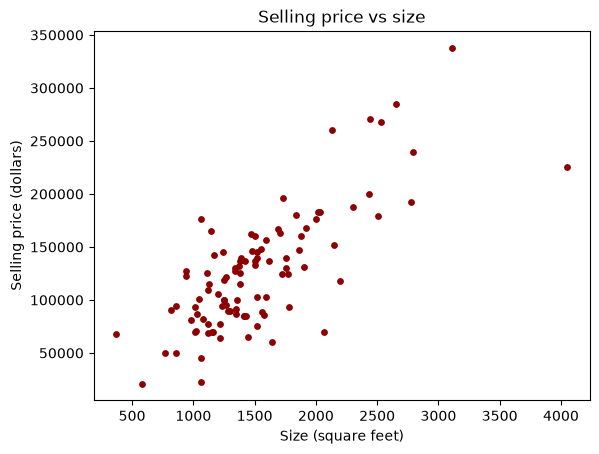

```python
plt.scatter(house['size'], house['price'], s=15, color="darkred")
plt.xlabel("Size (square feet)")
plt.ylabel("Selling price (dollars)")
plt.title("Selling price vs size")
plt.show()
```

The scatter plot shows a fairly strong, positive and approximately linear relationship between $x$ and $y$, where larger houses tend to sell for higher prices. The spread of $y$ appears roughly stable across the values of $x$.

One house, about 4000 square feet in size, lies far to the right of the other houses and sits below the general trend. We will come back to this point in part (j).

(c) Fit a simple linear regression model of $y$ on $x$ and write down the fitted model. Call this fitted model Model 1.

```python
model1 = smf.ols("price ~ size", data=house).fit()
print(model1.summary())
```

```
                            OLS Regression Results
==============================================================================
Dep. Variable:                  price   R-squared:                       0.580
Model:                            OLS   Adj. R-squared:                  0.575
Method:                 Least Squares   F-statistic:                     135.1
Date:                Tue, 20 Oct 2026   Prob (F-statistic):           3.84e-20
Time:                        00:45:13   Log-Likelihood:                -1192.0
No. Observations:                 100   AIC:                             2388.
Df Residuals:                      98   BIC:                             2393.
Df Model:                           1
Covariance Type:            nonrobust
==============================================================================
                 coef    std err          t      P>|t|      [0.025      0.975]
------------------------------------------------------------------------------
Intercept   9161.1589   1.08e+04      0.851      0.397   -1.22e+04    3.05e+04
size          77.0077      6.626     11.622      0.000      63.858      90.157
==============================================================================
Omnibus:                        1.224   Durbin-Watson:                   1.951
Prob(Omnibus):                  0.542   Jarque-Bera (JB):                0.717
Skew:                           0.030   Prob(JB):                        0.699
Kurtosis:                       3.410   Cond. No.                     4.76e+03
==============================================================================

Notes:
[1] Standard Errors assume that the covariance matrix of the errors is correctly specified.
[2] The condition number is large, 4.76e+03. This might indicate that there are
strong multicollinearity or other numerical problems.
```

From the output, the fitted equation of Model 1 is

$$ \hat{y} = 9161.159 + 77.008x. $$

(d) Test the significance of Model 1. Is $y$ independent of $x$?

```python
print(f"t = {model1.tvalues['size']:.3f}, p-value = {model1.pvalues['size']:.3g}")
print(f"F = {model1.fvalue:.2f}, p-value = {model1.f_pvalue:.3g}")
print(f"t^2 = {model1.tvalues['size']**2:.2f}")
```

```
t = 11.622, p-value = 3.84e-20
F = 135.07, p-value = 3.84e-20
t^2 = 135.07
```

The hypotheses are

$$ H_0: \beta_1 = 0 \quad \text{vs} \quad H_1: \beta_1 \ne 0 $$

where $\beta_1$ is the coefficient of $x$ in the simple model $y \sim x$.

Since this is a simple model, we can use either the $t$-test or the $F$-test:

- $t$-test: the test statistic is $t = 11.622$, whose null distribution is $t_{98}$ (since $df = n - 2 = 98$). The $p$-value is less than 0.001.
- $F$-test: the test statistic is $F = 135.1$, whose null distribution is $F_{1, 98}$. The $p$-value is the same as for the $t$-test. Note that $F = t^2 = 11.622^2 \approx 135.1$.

With a very small $p$-value, the data provide very strong evidence that Model 1 is significant, i.e. size is a significant regressor for the selling price. Hence, $y$ is not independent of $x$ and there is a significant linear relationship between them.

(e) Report a 99% confidence interval for the slope of Model 1.

```python
print(model1.conf_int(alpha=0.01).loc['size'])
```

```
0    59.601323
1    94.414062
Name: size, dtype: float64
```

The 99% confidence interval for the coefficient of $x$ is $(59.601,\ 94.414)$.

We are 99% confident that, for each additional square foot of size, the mean selling price increases by between 59.601 and 94.414 dollars.

(f) Derive the residual plots of Model 1: standardised residuals (SR) against the fitted response, SR against $x$, the histogram of SR and the QQ plot of SR. Identify any outliers and influential points. Comment on the adequacy of Model 1.

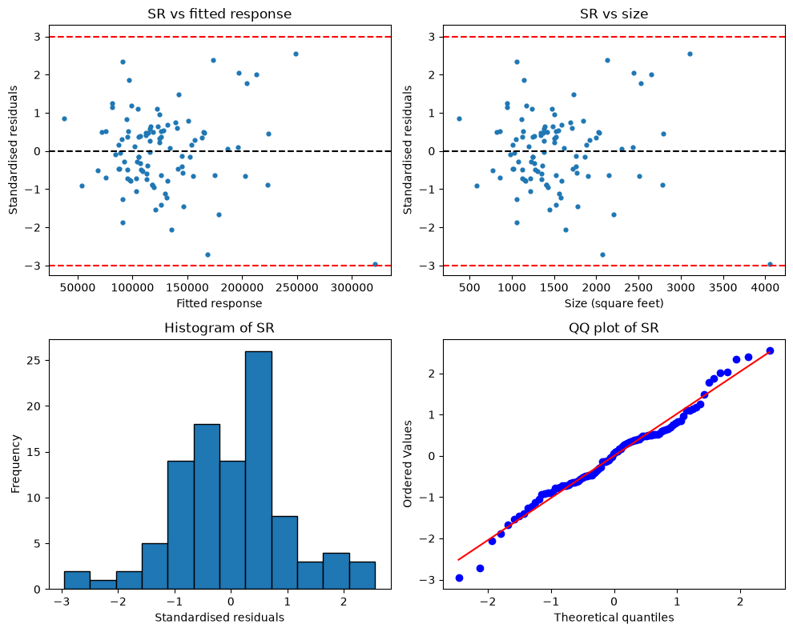

```python
influence1 = model1.get_influence()
SR = influence1.resid_studentized_internal
cooks = influence1.cooks_distance[0]

fig, axes = plt.subplots(2, 2, figsize=(10, 8))

axes[0, 0].scatter(model1.fittedvalues, SR, s=12)
axes[0, 0].axhline(0, color="black", linestyle="--")
axes[0, 0].axhline(3, color="red", linestyle="--")
axes[0, 0].axhline(-3, color="red", linestyle="--")
axes[0, 0].set_xlabel("Fitted response")
axes[0, 0].set_ylabel("Standardised residuals")
axes[0, 0].set_title("SR vs fitted response")

axes[0, 1].scatter(house['size'], SR, s=12)
axes[0, 1].axhline(0, color="black", linestyle="--")
axes[0, 1].axhline(3, color="red", linestyle="--")
axes[0, 1].axhline(-3, color="red", linestyle="--")
axes[0, 1].set_xlabel("Size (square feet)")
axes[0, 1].set_ylabel("Standardised residuals")
axes[0, 1].set_title("SR vs size")

axes[1, 0].hist(SR, bins=12, edgecolor="black")
axes[1, 0].set_xlabel("Standardised residuals")
axes[1, 0].set_ylabel("Frequency")
axes[1, 0].set_title("Histogram of SR")

stats.probplot(SR, plot=axes[1, 1])
axes[1, 1].set_title("QQ plot of SR")

plt.tight_layout()
plt.show()
```

```python
house["SR"] = SR
house["Cooks"] = cooks

# Outliers: |SR| > 3
print(f"Number of outliers (|SR| > 3): {np.sum(np.abs(SR) > 3)}")
print()

# Influential points: Cook's distance > 1
print("Influential points (Cook's distance > 1):")
print(house.loc[cooks > 1, ["House", "price", "size", "SR", "Cooks"]].round(3))
```

```
Number of outliers (|SR| > 3): 0

Influential points (Cook's distance > 1):
    House   price  size     SR  Cooks
63     64  225000  4050 -2.956  1.212
```

- SR vs fitted response and SR vs size: the points scatter randomly about 0, within the range $(-3, 3)$, with no obvious pattern or funnel shape. The linearity and constant variance assumptions appear reasonable.
- Histogram of SR: approximately symmetric and bell-shaped.
- QQ plot of SR: the points lie close to the reference line, with only slight deviations in the tails. The normality assumption appears reasonable.
- Outliers: no observation has $|SR| > 3$, so there are no outliers. House 64 comes closest, with an SR of about $-2.95$.
- Influential points: House 64 (size 4050 square feet, price 225,000 dollars) has a Cook's distance of about 1.21, which is greater than 1. It is an influential point.

Overall, the model assumptions appear to be satisfied, so Model 1 is reasonably adequate. However, House 64 is an influential point, and it should be investigated (see part (j)).

Note that an influential point does not have to be an outlier. House 64 has a standardised residual just inside $(-3, 3)$, but its size is far larger than that of the other houses, so it has a large effect on the fitted line.

(g) Derive the $R^2$ of Model 1 and interpret it. Verify that $\sqrt{R^2} = |cor(y, x)|$. In which situation do we have $\sqrt{R^2} = cor(y, x)$?

```python
print(f"R^2 = {model1.rsquared:.4f}")
print(f"sqrt(R^2) = {np.sqrt(model1.rsquared):.4f}")
```

```
R^2 = 0.5795
sqrt(R^2) = 0.7613
```

For Model 1, $R^2 = 0.5795$. This means that 57.95% of the variation in the selling price is explained by Model 1.

Indeed, $\sqrt{0.5795} = 0.7613 = |cor(y, x)|$.

In a simple model $y \sim x$, $\sqrt{R^2} = cor(y, x)$ when the estimated slope is positive (equivalently, $cor(y, x) > 0$). If the estimated slope is negative, $cor(y, x) = -\sqrt{R^2}$.

(h) Interpret the estimated slope of Model 1. Is the estimated intercept meaningful? Explain.

```python
print(f"Range of size: {house['size'].min()} to {house['size'].max()} square feet")
```

```
Range of size: 370 to 4050 square feet
```

Slope: for each additional square foot of size, the mean selling price is estimated to increase by 77.008 dollars.

Intercept: 9161.159 dollars is the estimated mean selling price of a house of size 0 square feet. This is not meaningful. A house of size 0 does not exist, and $x = 0$ is far outside the observed range of sizes (370 to 4050 square feet), so interpreting the intercept would be an extrapolation.

(i) Estimate the mean selling price of houses of size 2000 square feet, and give a 95% confidence interval for this mean. Would it be appropriate to use Model 1 to estimate the mean selling price of houses of size 6000 square feet?

```python
new_house = pd.DataFrame({'size': [2000]})
pred = model1.get_prediction(new_house).summary_frame(alpha=0.05)
print(pred[['mean', 'mean_ci_lower', 'mean_ci_upper']])
```

```
           mean  mean_ci_lower  mean_ci_upper
0  163176.54396  153588.646934  172764.440986
```

The estimated mean selling price of houses of size 2000 square feet is

$$ \hat{y} = 9161.159 + 77.008(2000) \approx 163{,}176.54 \text{ dollars}. $$

The 95% confidence interval for the mean response is $(153{,}588.65,\ 172{,}764.44)$. We are 95% confident that the true average selling price of all houses of size 2000 square feet lies within this interval.

Since 2000 lies within the observed range of sizes (370 to 4050 square feet), this is an interpolation.

It would not be appropriate to use Model 1 for houses of size 6000 square feet. This value is outside the observed range of sizes, so it would be an extrapolation. We do not know the form of the relationship outside the sampled values.

(j) Fit Model 1 again without the influential point found in part (f). Compare the estimated slope and $R^2$ with those of Model 1, and comment.

```python
house_no64 = house[house['House'] != 64]
model1b = smf.ols("price ~ size", data=house_no64).fit()

print(f"With House 64:    slope = {model1.params['size']:.3f}, R^2 = {model1.rsquared:.4f}")
print(f"Without House 64: slope = {model1b.params['size']:.3f}, R^2 = {model1b.rsquared:.4f}")
```

```
With House 64:    slope = 77.008, R^2 = 0.5795
Without House 64: slope = 87.085, R^2 = 0.6047
```

Without House 64, the estimated slope increases from 77.008 to 87.085, and $R^2$ increases from 0.5795 to 0.6047.

Removing a single house out of 100 changes the estimated slope by about 10 dollars per square foot. This confirms that House 64 is an influential point. It is much larger than the other houses but sold for a relatively low price, so it pulls the fitted line down at large sizes.

We should not drop the point automatically. It should be investigated (for example, whether it was recorded correctly, or whether it differs from the other houses in some important way) before deciding whether to keep it in the model.

### Question 2

Consider the dataset `house_selling_prices_FL.csv` again, where $y$ = selling price (dollars) and $x$ = the size of the house (square feet). The data have another variable, `NW`, which specifies whether a house is in the part of the town considered less desirable (`NW` = 0) or more desirable (`NW` = 1).

(a) Form a new model (called Model 2) which has two regressors, $x$ and `NW`. Write down the fitted equation of Model 2.

```python
model2 = smf.ols("price ~ size + C(NW)", data=house).fit()
print(model2.summary())
```

```
                            OLS Regression Results
==============================================================================
Dep. Variable:                  price   R-squared:                       0.635
Model:                            OLS   Adj. R-squared:                  0.628
Method:                 Least Squares   F-statistic:                     84.43
Date:                Tue, 20 Oct 2026   Prob (F-statistic):           5.79e-22
Time:                        00:45:14   Log-Likelihood:                -1184.9
No. Observations:                 100   AIC:                             2376.
Df Residuals:                      97   BIC:                             2384.
Df Model:                           2
Covariance Type:            nonrobust
==============================================================================
                 coef    std err          t      P>|t|      [0.025      0.975]
------------------------------------------------------------------------------
Intercept  -1.526e+04   1.19e+04     -1.281      0.203   -3.89e+04    8377.159
C(NW)[T.1]  3.057e+04   7948.742      3.846      0.000    1.48e+04    4.63e+04
size          77.9851      6.209     12.560      0.000      65.662      90.309
==============================================================================
Omnibus:                        5.936   Durbin-Watson:                   1.787
Prob(Omnibus):                  0.051   Jarque-Bera (JB):                6.175
Skew:                           0.368   Prob(JB):                       0.0456
Kurtosis:                       3.970   Cond. No.                     6.09e+03
==============================================================================

Notes:
[1] Standard Errors assume that the covariance matrix of the errors is correctly specified.
[2] The condition number is large, 6.09e+03. This might indicate that there are
strong multicollinearity or other numerical problems.
```

```python
# The summary rounds some values, so we also print the full estimates and p-values
print(model2.params)
print(model2.pvalues)
```

```
Intercept    -15257.513854
C(NW)[T.1]    30569.087289
size             77.985126
dtype: float64
Intercept     2.031602e-01
C(NW)[T.1]    2.149752e-04
size          4.690632e-22
dtype: float64
```

`NW` is a categorical variable, so we use `C(NW)`, which creates the indicator variable $I(\text{NW} = 1)$.

The fitted equation of Model 2 is

$$ \hat{y} = -15257.514 + 77.985x + 30569.087 I(\text{NW} = 1). $$

(b) Test the significance of `NW` in Model 2.

`NW` has two categories, so we can use the $t$-test from the summary table.

$$ H_0: \beta_2 = 0 \quad \text{vs} \quad H_1: \beta_2 \ne 0 $$

where $\beta_2$ is the coefficient of $I(\text{NW} = 1)$ in Model 2.

The test statistic is $t = 3.846$, whose null distribution is $t_{97}$ (since $df = n - 3 = 97$). The $p$-value is $0.000215 < 0.001$.

The data provide very strong evidence that `NW` is significant in Model 2.

(c) Report the coefficient of `NW` in Model 2. Interpret it.

The estimated coefficient of $I(\text{NW} = 1)$ in Model 2 is $30569.087$.

For two houses of the same size, the mean selling price of a house in the more desirable part of the town (`NW` = 1) is estimated to be 30,569.09 dollars higher than that of a house in the less desirable part (`NW` = 0).

(d) Estimate the mean selling price of a house of size 4000 square feet located in the more desirable part of the town. Comment on this estimate.

```python
print(model2.predict(pd.DataFrame({"size": [4000], "NW": [1]})))

# Range of sizes in each part of the town
size_nw0 = house.loc[house["NW"] == 0, "size"]
size_nw1 = house.loc[house["NW"] == 1, "size"]
print(f"NW = 0: {len(size_nw0)} houses, size from {size_nw0.min()} to {size_nw0.max()}")
print(f"NW = 1: {len(size_nw1)} houses, size from {size_nw1.min()} to {size_nw1.max()}")
```

```
0    327252.078939
dtype: float64
NW = 0: 25 houses, size from 1020 to 4050
NW = 1: 75 houses, size from 370 to 3110
```

The estimated mean selling price is

$$ \hat{y} = -15257.514 + 77.985(4000) + 30569.087 \approx 327{,}252.08 \text{ dollars}. $$

Although 4000 square feet lies within the overall range of sizes (370 to 4050 square feet), the houses in the more desirable part of the town (`NW` = 1) only range in size from 370 to 3110 square feet. The estimate therefore relies on the model's assumption that the effect of size is the same in both parts of the town, extended beyond the sizes observed for this group. In fact, only one house in the whole dataset is larger than 3110 square feet (House 64, in the less desirable part), so there is very little data near 4000 square feet. This estimate is effectively an extrapolation and should be treated with caution.

(e) Derive the $R^2$ of Model 2. Interpret it.

```python
print(f"R^2 = {model2.rsquared:.4f}, adjusted R^2 = {model2.rsquared_adj:.4f}")
```

```
R^2 = 0.6352, adjusted R^2 = 0.6276
```

Model 2 has $R^2 = 0.6352$, which means that 63.52% of the variation in the selling price is explained by Model 2.

(f) Compare Model 1 and Model 2. Which model fits the data better? Explain.

```python
print(f"Model 1: R^2 = {model1.rsquared:.4f}, adjusted R^2 = {model1.rsquared_adj:.4f}")
print(f"Model 2: R^2 = {model2.rsquared:.4f}, adjusted R^2 = {model2.rsquared_adj:.4f}")
```

```
Model 1: R^2 = 0.5795, adjusted R^2 = 0.5752
Model 2: R^2 = 0.6352, adjusted R^2 = 0.6276
```

The two models have a different number of regressors, so we compare them using the adjusted $R^2$ rather than $R^2$. $R^2$ never decreases when a regressor is added, even if it contributes little.

The adjusted $R^2$ increases from 0.5752 (Model 1) to 0.6276 (Model 2), and `NW` is a highly significant regressor (part (b)). Model 2 fits the data better.

### Question 3

Consider the dataset `house_selling_prices_FL.csv` again. We now investigate whether a curved relationship between $y$ = selling price and $x$ = size fits the data better.

(a) Fit a model (called Model 3) with regressors $x$ and $x^2$. Write down the fitted equation of Model 3. Is Model 3 a linear regression model?

```python
model3 = smf.ols("price ~ size + I(size**2)", data=house).fit()
print(model3.summary())
```

```
                            OLS Regression Results
==============================================================================
Dep. Variable:                  price   R-squared:                       0.584
Model:                            OLS   Adj. R-squared:                  0.575
Method:                 Least Squares   F-statistic:                     68.01
Date:                Tue, 20 Oct 2026   Prob (F-statistic):           3.46e-19
Time:                        00:45:14   Log-Likelihood:                -1191.5
No. Observations:                 100   AIC:                             2389.
Df Residuals:                      97   BIC:                             2397.
Df Model:                           2
Covariance Type:            nonrobust
================================================================================
                   coef    std err          t      P>|t|      [0.025      0.975]
--------------------------------------------------------------------------------
Intercept    -1.135e+04   2.33e+04     -0.486      0.628   -5.77e+04     3.5e+04
size           101.3405     25.440      3.984      0.000      50.850     151.831
I(size ** 2)    -0.0063      0.006     -0.991      0.324      -0.019       0.006
==============================================================================
Omnibus:                        1.331   Durbin-Watson:                   1.949
Prob(Omnibus):                  0.514   Jarque-Bera (JB):                0.808
Skew:                           0.133   Prob(JB):                        0.668
Kurtosis:                       3.351   Cond. No.                     2.19e+07
==============================================================================

Notes:
[1] Standard Errors assume that the covariance matrix of the errors is correctly specified.
[2] The condition number is large, 2.19e+07. This might indicate that there are
strong multicollinearity or other numerical problems.
```

```python
# The summary rounds some values, so we also print the full estimates
print(model3.params)
```

```
Intercept      -11347.885899
size              101.340526
I(size ** 2)       -0.006307
dtype: float64
```

The fitted equation of Model 3 is

$$ \hat{y} = -11347.886 + 101.341x - 0.006307x^2. $$

Model 3 is still a linear regression model, because it is linear in the coefficients $\beta_0$, $\beta_1$ and $\beta_2$. The higher-order term $x^2$ allows it to capture a curved relationship.

(b) Test the significance of the quadratic term at significance level 0.05.

```python
print(model3.tvalues)
print()
print(model3.pvalues)
```

```
Intercept      -0.486376
size            3.983551
I(size ** 2)   -0.990690
dtype: float64

Intercept       0.627797
size            0.000131
I(size ** 2)    0.324302
dtype: float64
```

$$ H_0: \beta_2 = 0 \quad \text{vs} \quad H_1: \beta_2 \ne 0 $$

where $\beta_2$ is the coefficient of $x^2$ in Model 3.

The test statistic is $t = -0.991$, whose null distribution is $t_{97}$ (since $df = n - 3 = 97$), and the $p$-value is 0.324 > 0.05. We do not reject $H_0$ and conclude that there is insufficient evidence that the quadratic term is needed.

(c) Using Model 3, by how much is the mean selling price estimated to change when the size of a house increases from $x$ to $(x + 1)$ square feet? Evaluate this at $x = 1500$, and compare with Model 1.

```python
b = model3.params
x = 1500
print(f"Change from 1500 to 1501: {b['size'] + b['I(size ** 2)'] * (2 * x + 1):.3f}")

# Check directly
print(f"Direct check: {(model3.predict(pd.DataFrame({'size': [x + 1]})) - model3.predict(pd.DataFrame({'size': [x]})))[0]:.3f}")
```

```
Change from 1500 to 1501: 82.414
Direct check: 82.414
```

Write $\hat{y}(x) = \hat{\beta}_0 + \hat{\beta}_1 x + \hat{\beta}_2 x^2$. When size increases by one unit,

$$ \begin{aligned} \hat{y}(x+1) - \hat{y}(x) &= \hat{\beta}_1 (x+1) + \hat{\beta}_2 (x+1)^2 - \hat{\beta}_1 x - \hat{\beta}_2 x^2 \\ &= \hat{\beta}_1 + \hat{\beta}_2 (2x + 1). \end{aligned} $$

Unlike in Model 1, the change depends on $x$, the size before the increase. At $x = 1500$:

$$ 101.341 - 0.006307 \times 3001 \approx 82.414. $$

So in Model 3, the mean selling price is estimated to increase by about 82.414 dollars when the size increases from 1500 to 1501 square feet. In Model 1, the estimated increase is 77.008 dollars for every additional square foot, regardless of the size.

(d) Compare Model 1 and Model 3 using $R^2$ and adjusted $R^2$. Which model would you prefer?

```python
print(f"Model 1: R^2 = {model1.rsquared:.4f}, adjusted R^2 = {model1.rsquared_adj:.4f}")
print(f"Model 3: R^2 = {model3.rsquared:.4f}, adjusted R^2 = {model3.rsquared_adj:.4f}")
```

```
Model 1: R^2 = 0.5795, adjusted R^2 = 0.5752
Model 3: R^2 = 0.5837, adjusted R^2 = 0.5751
```

$R^2$ increases slightly, from 0.5795 to 0.5837, but this is expected as $R^2$ never decreases when a regressor is added, even if it contributes little.

The adjusted $R^2$, which takes into account the number of regressors, slightly decreases from 0.5752 to 0.5751. Together with the non-significant quadratic term in part (b), this shows that the quadratic term does not improve the model. We would prefer the simpler Model 1.

This is consistent with the scatter plot in Question 1(b), which shows an approximately linear relationship.

### Question 4

A real estate agent in another town models the selling price $Y$ (dollars) of a house using its size $X$ (square feet) and the quadrant of the town where it is located. The variable `Quadrant` has four categories: NE, NW, SE and SW. The agent fits the model

$$ Y = \beta_0 + \beta_1 X + \beta_2 I(\text{Quadrant}=\text{NE}) + \beta_3 I(\text{Quadrant}=\text{NW}) + \beta_4 I(\text{Quadrant}=\text{SE}) + \varepsilon, $$

where, for example, $I(\text{Quadrant}=\text{NE}) = 1$ if the house is in the NE quadrant and 0 otherwise.

(a) `Quadrant` has four categories. Why does the model contain only three indicator variables? Which quadrant is the baseline category?

A categorical variable with $k$ categories usually needs $k - 1$ indicator variables. `Quadrant` has 4 categories, so the model has 3 indicator variables.

The category without its own indicator variable is the baseline. Here, the baseline category is SW. So, for a house in SW, all three indicators equal 0.

(b) The fitted model is

$$ \hat{Y} = 10000 + 80X + 25000 I(\text{Quadrant}=\text{NE}) + 30000 I(\text{Quadrant}=\text{NW}) - 5000 I(\text{Quadrant}=\text{SE}). $$

Write down the fitted equations for houses in each of the four quadrants. Hence, estimate the mean selling price of houses of size 1500 square feet in the NE quadrant.

- NE: $\hat{Y} = 10000 + 80X + 25000 = 35000 + 80X$
- NW: $\hat{Y} = 10000 + 80X + 30000 = 40000 + 80X$
- SE: $\hat{Y} = 10000 + 80X - 5000 = 5000 + 80X$
- SW (baseline): $\hat{Y} = 10000 + 80X$

For a house of size 1500 square feet in NE:

$$ \hat{Y} = 35000 + 80(1500) = 155{,}000 \text{ dollars}. $$

(c) Interpret the coefficient 30000 of $I(\text{Quadrant}=\text{NW})$. For two houses of the same size, how much higher is the estimated mean selling price in NW than in NE?

For houses of the same size, the mean selling price in the NW quadrant is estimated to be 30,000 dollars higher than in the SW quadrant (the baseline).

Each indicator coefficient compares a quadrant with the baseline. To compare NW with NE, we take the difference of their coefficients: $30000 - 25000 = 5000$. For two houses of the same size, the estimated mean selling price in NW is 5,000 dollars higher than in NE.

(d) After fitting the model, the agent plots the standardised residuals against the fitted response and sees a clear funnel shape. Which model assumption is violated? Suggest a possible fix, and explain how the fix changes the interpretation of the new $\beta_1$.

A funnel shape means that the spread of the residuals changes with the fitted response, so the constant variance assumption is violated.

A possible fix is to transform the response, for example by fitting $\log(Y)$, $\sqrt{Y}$ or $1/Y$ instead of $Y$.

Transforming $Y$ changes the interpretation of the coefficients. For example, in the model

$$ \log(Y) = \beta_0 + \beta_1 X + \beta_2 I(\text{Quadrant}=\text{NE}) + \beta_3 I(\text{Quadrant}=\text{NW}) + \beta_4 I(\text{Quadrant}=\text{SE}) + \varepsilon, $$

$\beta_1$ is the increase in $\log(Y)$, not in $Y$, for every one-unit increase in $X$, holding the quadrant fixed.